# Time-Series Clustering in R Using the dtwclust Package

Most clustering strategies have not changed considerably since their initial definition. The common improvements are either related to the distance measure used to assess dissimilarity, or the function used to calculate prototypes. Time-series clustering is no exception, with the Dynamic Time Warping distance being particularly popular in that context. This distance is computationally expensive, so many related optimizations have been developed over the years. Since no single clustering algorithm can be said to perform best on all datasets, different strategies must be tested and compared, so a common infrastructure can be advantageous. In this manuscript, a general overview of shape-based time-series clustering is given, including many specifics related to Dynamic Time Warping and associated techniques. At the same time, a description of the [*dtwclust*](https://CRAN.R-project.org/package=dtwclust) package for the R statistical software is provided, showcasing how it can be used to evaluate many different time-series clustering procedures.

Alexis Sardá-Espinosa (.na.character)  
2019-08-16

## 1 Introduction

Cluster analysis is a task that concerns itself with the creation of groups of objects, where each group is called a cluster. Ideally, all members of the same cluster are similar to each other, but are as dissimilar as possible from objects in a different cluster. There is no single definition of a cluster, and the characteristics of the objects to be clustered vary. Thus, there are several algorithms to perform clustering. Each one defines specific ways of defining what a cluster is, how to measure similarities, how to find groups efficiently, etc. Additionally, each application might have different goals, so a certain clustering algorithm may be preferred depending on the type of clusters sought (Kaufman and Rousseeuw 1990).

Clustering algorithms can be organized differently depending on how they handle the data and how the groups are created. When it comes to static data, i.e., if the values do not change with time, clustering methods can be divided into five major categories: partitioning (or partitional), hierarchical, density-based, grid-based, and model-based methods (Liao 2005; Rani and Sikka 2012). They may be used as the main algorithm, as an intermediate step, or as a preprocessing step (Aghabozorgi et al. 2015).

Time-series is a common type of dynamic data that naturally arises in many different scenarios, such as stock data, medical data, and machine monitoring, just to name a few (Aggarwal and Reddy 2013; Aghabozorgi et al. 2015). They pose some challenging issues due to the large size and high dimensionality commonly associated with time-series (Aghabozorgi et al. 2015). In this context, dimensionality of a series is related to time, and it can be understood as the length of the series. Additionally, a single time-series object may be constituted by several values that change on the same time scale, in which case they are identified as multivariate time-series.

There are many techniques to modify time-series in order to reduce dimensionality, and they mostly deal with the way time-series are represented. Changing representation can be an important step, not only in time-series clustering, and it constitutes a wide research area on its own (cf. Table 2 in Aghabozorgi et al. (2015)). While choice of representation can directly affect clustering, it can be considered as a different step, and as such it will not be discussed further here.

Time-series clustering is a type of clustering algorithm made to handle dynamic data. The most important elements to consider are the (dis)similarity or distance measure, the prototype extraction function (if applicable), the clustering algorithm itself, and cluster evaluation (Aghabozorgi et al. 2015). In many cases, algorithms developed for time-series clustering take static clustering algorithms and either modify the similarity definition, or the prototype extraction function to an appropriate one, or apply a transformation to the series so that static features are obtained (Liao 2005). Therefore, the underlying basis for the different clustering procedures remains approximately the same across clustering methods. The most common approaches are hierarchical and partitional clustering (cf. Table 4 in Aghabozorgi et al. (2015)), the latter of which includes fuzzy clustering.

Aghabozorgi et al. (2015) classify time-series clustering algorithms based on the way they treat the data and how the underlying grouping is performed. One classification depends on whether the whole series, a subsequence, or individual time points are to be clustered. On the other hand, the clustering itself may be shape-based, feature-based, or model-based. Aggarwal and Reddy (2013) make an additional distinction between online and offline approaches, where the former usually deals with grouping incoming data streams on-the-go, while the latter deals with data that no longer change.

In the context of shape-based time-series clustering, it is common to utilize the Dynamic Time Warping (DTW) distance as dissimilarity measure (Aghabozorgi et al. 2015). The calculation of the DTW distance involves a dynamic programming algorithm that tries to find the optimum warping path between two series under certain constraints. However, the DTW algorithm is computationally expensive, both in time and memory utilization. Over the years, several variations and optimizations have been developed in an attempt to accelerate or optimize the calculation. Some of the most common techniques will be discussed in more detail in 2.1.

The choice of time-series representation, preprocessing, and clustering algorithm has a big impact on performance with respect to cluster quality and execution time. Similarly, different programming languages have different run-time characteristics and user interfaces, and even though many authors make their algorithms publicly available, combining them is far from trivial. As such, it is desirable to have a common platform on which clustering algorithms can be tested and compared against each other. The *dtwclust* package, developed for the R statistical software, and part of its [*TimeSeries*](https://CRAN.R-project.org/view=TimeSeries) view, provides such functionality, and includes implementations of recently developed time-series clustering algorithms and optimizations. It serves as a bridge between classical clustering algorithms and time-series data, additionally providing visualization and evaluation routines that can handle time-series. All of the included algorithms are custom implementations, except for the hierarchical clustering routines. A great amount of effort went into implementing them as efficiently as possible, and the functions were designed with flexibility and extensibility in mind.

Most of the included algorithms and optimizations are tailored to the DTW distance, hence the package’s name. However, the main clustering function is flexible so that one can test many different clustering approaches, using either the time-series directly, or by applying suitable transformations and then clustering in the resulting space. We will describe the new algorithms that are available in *dtwclust*, mentioning the most important characteristics of each, and showing how the package can be used to evaluate them, as well as how other packages complement it. Additionally, the variations related to DTW and other common distances will be explored.

There are many available R packages for data clustering. The [*flexclust*](https://CRAN.R-project.org/package=flexclust) package (Leisch 2006) implements many partitional procedures, while the [*cluster*](https://CRAN.R-project.org/package=cluster) package (Maechler et al. 2019) focuses more on hierarchical procedures and their evaluation; neither of them, however, is specifically targeted at time-series data. Packages like [*TSdist*](https://CRAN.R-project.org/package=TSdist) (Mori et al. 2016) and [*TSclust*](https://CRAN.R-project.org/package=TSclust) (Montero and Vilar 2014) focus solely on dissimilarity measures for time-series, the latter of which includes a single algorithm for clustering based on $p$ values. Another example is the [*pdc*](https://CRAN.R-project.org/package=pdc) package (Brandmaier 2015), which implements a specific clustering algorithm, namely one based on permutation distributions. The [*dtw*](https://CRAN.R-project.org/package=dtw) package (Giorgino 2009) implements extensive functionality with respect to DTW, but does not include the lower bound techniques that can be very useful in time-series clustering. New clustering algorithms like *k*-Shape (Paparrizos and Gravano 2015) and TADPole (Begum et al. 2015) are available to the public upon request, but were implemented in MATLAB, making their combination with other R packages cumbersome. Hence, the *dtwclust* package is intended to provide a consistent and user-friendly way of interacting with classic and new clustering algorithms, taking into consideration the nuances of time-series data.

The rest of this manuscript presents the different logical units required for a time-series clustering workflow, and specifies how they are implemented in *dtwclust*. These build on top of each other and are not entirely independent, so their coherent combination is critical. The information relevant to the distance measures will be presented in 2. Supported algorithms for prototype extraction will be discussed in 3. The main clustering algorithms will be introduced in 4. Information regarding cluster evaluation will be provided in 5. The provided tools for a complete time-series clustering workflow will be described in 6, and the final remarks will be given in 7. Note that code examples are intentionally brief, and do not necessarily represent a thorough procedure to choose or evaluate a clustering algorithm. The data used in all examples is included in the package (saved in a list called `CharTraj`), and is a subset of the character trajectories dataset found in Lichman (2013): they are pen tip trajectories recorded for individual characters, and the subset contains 5 examples of the $x$ velocity for each considered character.

## 2 Distance measures

Distance measures provide quantification for the dissimilarity between two time-series. Calculating distances, as well as cross-distance matrices, between time-series objects is one of the cornerstones of any time-series clustering algorithm. The [*proxy*](https://CRAN.R-project.org/package=proxy) package (Meyer and Buchta 2019) provides an extensible framework for these calculations, and is used extensively by *dtwclust*; 2.5 will elaborate in this regard.

The $l_1$ and $l_2$ vector norms, also known as Manhattan and Euclidean distances respectively, are the most commonly used distance measures, and are arguably the only competitive $l_p$ norms when measuring dissimilarity (Aggarwal et al. 2001; Lemire 2009). They can be efficiently computed, but are only defined for series of equal length and are sensitive to noise, scale, and time shifts. Thus, many other distance measures tailored to time-series have been developed in order to overcome these limitations, as well as other challenges associated with the structure of time-series, such as multiple variables, serial correlation, etc.

In the following sections a description of the distance functions included in *dtwclust* will be provided; these are associated with shape-based time-series clustering, and either support DTW or provide an alternative to it. The included distances are a basis for some of the prototyping functions described in 3, as well as the clustering routines from 4, but there are many other distance measures that can be used for time-series clustering and classification (Montero and Vilar 2014; Mori et al. 2016). It is worth noting that, even though some of these distances are also available in other R packages, e.g., DTW in *dtw* or Keogh’s DTW lower bound in *TSdist* (see 2.1), the implementations in *dtwclust* are optimized for speed, since all of them are implemented in C++ and have custom loops for computation of cross-distance matrices, including multi-threading support; refer to 2.6 for more information.

To facilitate notation, we define a time-series as a vector (or set of vectors in case of multivariate series) $x$. Each vector must have the same length for a given time-series. In general, $x^v_i$ represents the $i$-th element of the $v$-th variable of the (possibly multivariate) time-series $x$. We will assume that all elements are equally spaced in time in order to avoid the time index explicitly.

### 2.1 Dynamic time warping distance

DTW is a dynamic programming algorithm that compares two series and tries to find the optimum warping path between them under certain constraints, such as monotonicity (Berndt and Clifford 1994). It started being used by the data mining community to overcome some of the limitations associated with the Euclidean distance (Ratanamahatana and Keogh 2004).

The easiest way to get an intuition of what DTW does is graphically. 1 shows the alignment between two sample time-series $x$ and $y$. In this instance, the initial and final points of the series must match, but other points may be warped in time in order to find better matches.

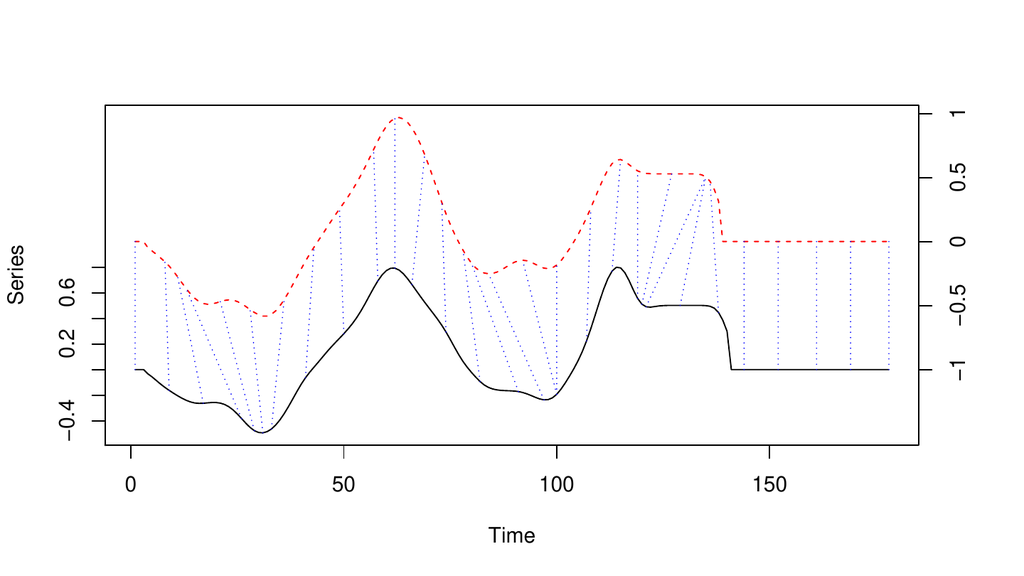

Figure 1: Sample alignment performed by the DTW algorithm between two series. The dashed blue lines exemplify how some points are mapped to each other, which shows how they can be warped in time. Note that the vertical position of each series was artificially altered for visualization.

DTW is computationally expensive. If $x$ has length $n$ and $y$ has length $m$, the DTW distance between them can be computed in $O(nm)$ time, which is quadratic if $m$ and $n$ are similar. Additionally, DTW is prone to implementation bias since its calculations are not easily vectorized and tend to be very slow in non-compiled programming languages. A custom implementation of the DTW algorithm is included with *dtwclust* in the `dtw_basic` function, which has only basic functionality but still supports the most common options, and it is faster (see 2.6).

The DTW distance can potentially deal with series of different length directly. This is not necessarily an advantage, as it has been shown before that performing linear reinterpolation to obtain equal length may be appropriate if $m$ and $n$ do not vary significantly (Ratanamahatana and Keogh 2004). For a more detailed explanation of the DTW algorithm see, e.g., Giorgino (2009). However, there are some aspects that are worth discussing here.

The first step in DTW involves creating a local cost matrix (LCM or $lcm$), which has $n \times m$ dimensions. Such a matrix must be created for every pair of distances compared, meaning that memory requirements may grow quickly as the dataset size grows. Considering $x$ and $y$ as the input series, for each element $(i,j)$ of the LCM, the $l_p$ norm between $x_i$ and $y_j$ must be computed. This is defined in (1), explicitly denoting that multivariate series are supported as long as they have the same number of variables (note that for univariate series, the LCM will be identical regardless of the used norm). Thus, it makes sense to speak of a $\text{DTW}_p{}$ distance, where $p$ corresponds to the $l_p$ norm that was used to construct the LCM.

$$\label{eq:lcm}
lcm(i,j) = \left( \sum_v \lvert x^v_i - y^v_j \rvert ^ p \right) ^ {1/p} \tag{1}$$

In the seconds step, the DTW algorithm finds the path that minimizes the alignment between $x$ and $y$ by iteratively stepping through the LCM, starting at $lcm(1,1)$ and finishing at $lcm(n,m)$, and aggregating the cost. At each step, the algorithm finds the direction in which the cost increases the least under the chosen constraints.

The way in which the algorithm traverses through the LCM is primarily dictated by the chosen step pattern. It is a local constraint that determines which directions are allowed when moving ahead in the LCM as the cost is being aggregated, as well as the associated per-step weights. 2 depicts two common step patterns and their names in the *dtw* package. Unfortunately, very few articles from the data mining community specify which pattern they use, although in the author’s experience, the `symmetric1` pattern seems to be standard. By contrast, the `dtw` and `dtw_basic` functions use the `symmetric2` pattern by default, but it is simple to modify this by providing the appropriate value in the `step.pattern` argument. The choice of step pattern also determines whether the corresponding DTW distance can be normalized or not (which may be important for series with different length). See Giorgino (2009) for a complete list of step patterns and to know which ones can be normalized.

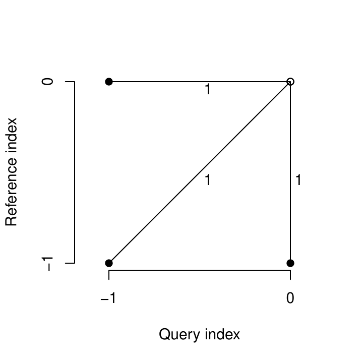

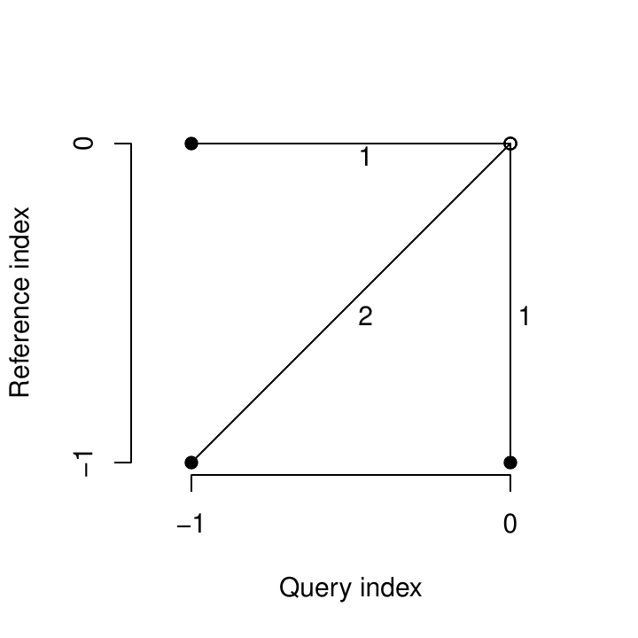

1. `symmetric1` step pattern
2. `symmetric2` step pattern

Figure 2: Two common step patterns used by DTW when traversing the LCM. At each step, the lines denote the allowed directions that can be taken, as well as the weight associated with each one.

It should be noted that the DTW distance does not satisfy the triangle inequality, and it is not symmetric in general, e.g., for asymmetric step patterns (Giorgino 2009). The patterns in 2 can result in a symmetric DTW calculation, provided no constraints are used (see the next section), or all series have the same length if a constraint is indeed used.

#### Global DTW constraints

One of the possible modifications of DTW is to use global constraints, also known as window constraints. These limit the area of the LCM that can be reached by the algorithm. There are many types of windows (see, e.g., Giorgino (2009)), but one of the most common ones is the Sakoe-Chiba window (Sakoe and Chiba 1978), with which an allowed region is created along the diagonal of the LCM (see 3). These constraints can marginally speed up the DTW calculation, but they are mainly used to avoid pathological warping. It is common to use a window whose size is 10% of the series’ length, although sometimes smaller windows produce even better results (Ratanamahatana and Keogh 2004).

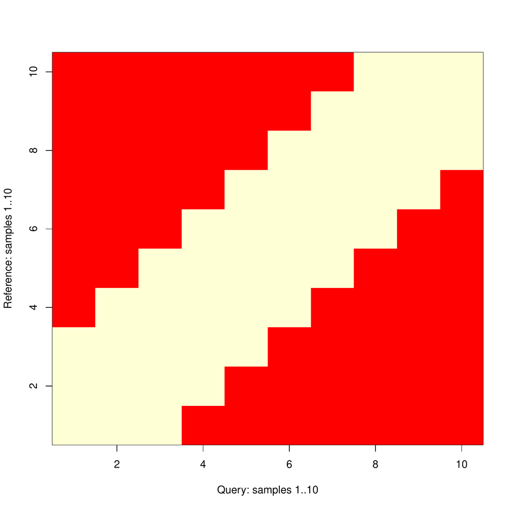

Figure 3: Visual representation of the Sakoe-Chiba constraint for DTW. The red elements will not be considered by the algorithm when traversing the LCM.

Strictly speaking, if the series being compared have different lengths, a constrained path may not exist, since the Sakoe-Chiba band may prevent the end point of the LCM to be reached (Giorgino 2009). In these cases a slanted band window may be preferred, since it stays along the diagonal for series of different length and is equivalent to the Sakoe-Chiba window for series of equal length. If a window constraint is used with *dtwclust*, a slanted band is employed.

It is not possible to know a priori what window size, if any, will be best for a specific application, although it is usually agreed that no constraint is a poor choice. For this reason, it is better to perform tests with the data one wants to work with, perhaps taking a subset to avoid excessive running times.

It should be noted that, when reported, window sizes are always integers greater than zero. If we denote this number with $w$, and for the specific case of the slanted band window, the valid region of the LCM will be constituted by all valid points in the range $\left[ (i,j - w), (i, j + w) \right]$ for all $(i,j)$ along the LCM diagonal. Thus, at each step, at most $2w + 1$ elements may fall within the window for a given window size $w$. This is the convention followed by *dtwclust*.

#### Lower bounds for DTW

Due to the fact that DTW itself is expensive to compute, lower bounds (LBs) for the DTW distance have been developed. These lower bounds guarantee being less than or equal to the corresponding DTW distance. They have been exploited when indexing time-series databases, classification of time-series, clustering, etc. (Keogh and Ratanamahatana 2005; Begum et al. 2015). Out of the existing DTW LBs, the two most effective are termed `LB_Keogh` (Keogh and Ratanamahatana 2005) and `LB_Improved` (Lemire 2009). The reader is referred to the respective articles for detailed definitions and proofs of the LBs, however some important considerations will be further discussed here.

Each LB can be computed with a specific $l_p$ norm. Therefore, it follows that the $l_p$ norms used for DTW and LB calculations must match, such that $\text{LB}_p \leq \text{DTW}_p{}$. Moreover, $\text{LB\_Keogh}_p \leq \text{LB\_Improved}_p \leq \text{DTW}_p{}$, meaning that `LB_Improved` can provide a tighter LB. It must be noted that the LBs are only defined for series of equal length and are not symmetric regardless of the $l_p$ norm used to compute them. Also note that the choice of step pattern affects the value of the DTW distance, changing the tightness of a given LB.

One crucial step when calculating the LBs is the computation of the so-called envelopes. These envelopes require a window constraint, and are thus dependent on both the type and size of the window. Based on these, a running minimum and maximum are computed, and a lower and upper envelope are generated respectively. 4 depicts a sample time-series with its corresponding envelopes for a Sakoe-Chiba window of size 15.

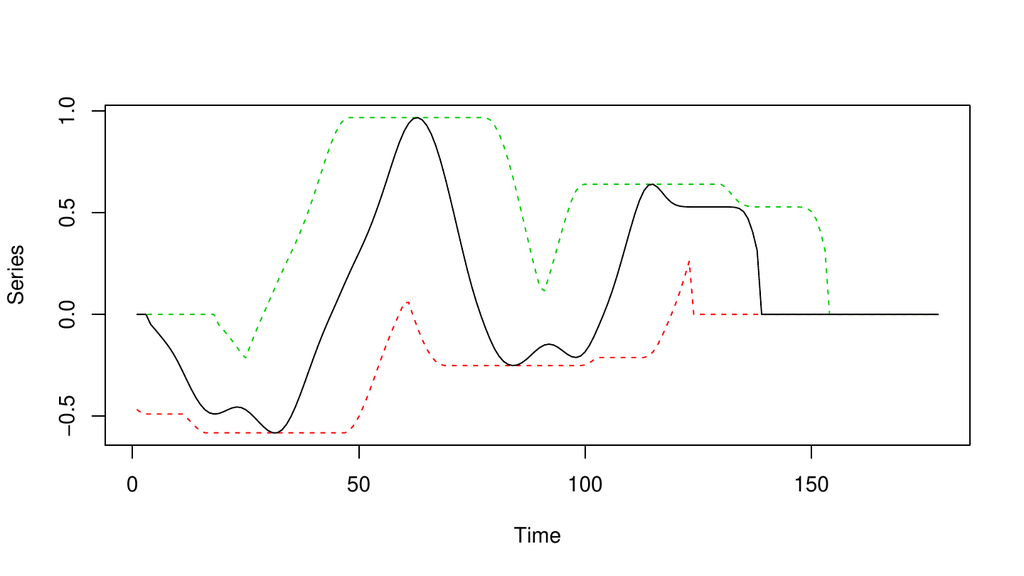

Figure 4: Visual representation of a time-series (shown as a solid black line) and its corresponding envelopes based on a Sakoe-Chiba window of size 15. The green dashed line represents the upper envelope, while the red dashed line represents the lower envelope.

In order for the LBs to be worth it, they must be computed in significantly less time than it takes to calculate the DTW distance. Lemire (2009) developed a streaming algorithm to calculate the envelopes using no more than $3n$ comparisons when using a Sakoe-Chiba window. This algorithm has been ported to *dtwclust* using the C++ programming language, ensuring an efficient calculation, and it is exposed in the `compute_envelope` function.

`LB_Keogh` requires the calculation of one set of envelopes for every pair of series compared, whereas `LB_Improved` must calculate two sets of envelopes for every pair of series. If the LBs must be calculated between several time-series, some envelopes can be reused when a given series is compared against many others. This optimization is included in the LB functions registered with *proxy* by *dtwclust*.

### 2.2 Global alignment kernel distance

Cuturi (2011) proposed an algorithm to assess similarity between time series by using kernels. He began by formalizing an alignment between two series $x$ and $y$ as $\pi$, and defined the set of all possible alignments as $\mathcal{A}(n,m)$, which is constrained by the lengths of $x$ and $y$. It is shown that the DTW distance can be understood as the cost associated with the minimum alignment.

A Global Alignment (GA) kernel that considers the cost of all possible alignments by computing their exponentiated soft-minimum is defined, and it is argued that it quantifies similarities in a more coherent way. However, the GA kernel has associated limitations, namely diagonal dominance and a complexity $O(nm)$. With respect to the former, Cuturi (2011) states that diagonal dominance should not be an issue as long as one of the series being compared is not longer than twice the length of the other.

In order to reduce the GA kernel’s complexity, Cuturi (2011) proposed using the triangular local kernel for integers shown in (2), where $T$ represents the kernel’s order. By combining it with the kernel $\kappa$ in (3) (which is based on the Gaussian kernel $\kappa_\sigma$), the Triangular Global Alignment Kernel (TGAK) in (4) is obtained. Such a kernel can be computed in $O(T \min(n,m))$, and is parameterized by the triangular constraint $T$ and the Gaussian’s kernel width $\sigma$.

$$\label{eq:int-kernel}
\omega(i,j) = \left( 1 - \frac{|i - j|}{T} \right)_{+} \tag{2}$$

$$\label{eq:phi-kernel}
\begin{gather}
\kappa (x,y) = e ^ {-\phi_\sigma(x,y)} \\
\phi_\sigma(x,y) = \frac{1}{2 \sigma ^ 2} \left\lVert x - y \right\rVert ^ 2 + \log \left( 2 - e ^ {-\frac{\left\lVert x - y \right\rVert ^ 2}{2 \sigma ^ 2}} \right)
\end{gather} \tag{3}$$

$$\label{eq:tga-kernel}
\text{TGAK}(x,y,\sigma,T) = \tau ^ {-1} \left( \omega \otimes \frac{1}{2} \kappa \right) (i,x;j,y) = \frac{\omega(i,j) \kappa (x,y)}{2 - \omega(i,j) \kappa (x,y)} \tag{4}$$

The triangular constraint is similar to the window constraints that can be used in the DTW algorithm. When $T = 0$ or $T \rightarrow \infty$, the TGAK converges to the original GA kernel. When $T = 1$, the TGAK becomes a slightly modified Gaussian kernel that can only compare series of equal length. If $T > 1$, then only the alignments that fulfil $-T < \pi_1(i) - \pi_2(i) < T$ are considered.

Cuturi (2011) also proposed a strategy to estimate the value of $\sigma$ based on the time-series themselves and their lengths, namely $c \cdot \text{med}(\left\lVert x - y \right\rVert) \cdot \sqrt{\text{med}(|\text{x}|)}$, where $\text{med}(\cdot)$ is the empirical median, $c$ is some constant, and $x$ and $y$ are subsampled vectors from the dataset. This, however, introduces some randomness into the algorithm when the value of $\sigma$ is not provided, so it might be better to estimate it once and re-use it in subsequent function evaluations. In *dtwclust*, the value of $c$ is set to 1.

The similarity returned by the TGAK can be normalized with (5) so that its values lie in the range $[0,1]$. Hence, a distance measure for time-series can be obtained by subtracting the normalized value from 1. The algorithm supports multivariate series and series of different length (with some limitations). The resulting distance is symmetric and satisfies the triangle inequality, although it is more expensive to compute in comparison to DTW.

$$\label{eq:tgak-norm}
\exp \left( \log\left( \text{TGAK}(x,y,\sigma,T) \right) - \frac{\log\left( \text{TGAK}(x,x,\sigma,T) \right) + \log\left( \text{TGAK}(y,y,\sigma,T) \right)}{2} \right) \tag{5}$$

A C implementation of the TGAK algorithm is available at its author’s website [^1]. An R wrapper has been implemented in *dtwclust* in the `GAK` function, performing the aforementioned normalization and subtraction in order to obtain a distance measure that can be used in clustering procedures.

### 2.3 Soft-DTW

Following with the idea of the TGAK, i.e., of regularizing DTW by smoothing it, Cuturi and Blondel (2017) proposed a unified algorithm using a parameterized soft-minimum as shown in (6) (where $\Delta(x,y)$ represents the LCM), and called the resulting discrepancy a soft-DTW, discussing its differentiability. Thanks to this property, a gradient function can be obtained, and Cuturi and Blondel (2017) developed a more efficient way to compute it. This can be then used to calculate centroids with numerical optimization as discussed in 3.3.

$$\label{eq:soft-dtw}
\begin{gather}
\text{dtw}_\gamma(x,y) = \text{min} ^ \gamma \lbrace \langle A, \Delta(x,y) \rangle, A \in \mathcal{A}(n,m) \rbrace \\
\text{min} ^ \gamma \lbrace a_1, \ldots, a_n \rbrace =
\begin{cases}
\text{min}_{i \leq n} a_i, \quad \gamma = 0 \\
-\gamma \log \sum_{i=1}^{n} e^{-a_i / \gamma}, \quad \gamma > 0
\end{cases}
\end{gather} \tag{6}$$

However, as a stand-alone distance measure, the soft-DTW distance has some disadvantages: the distance can be negative, the distance between $x$ and itself is *not* necessarily zero, it does not fulfill the triangle inequality, and also has quadratic complexity with respect to the series’ lengths. On the other hand, it is a symmetric distance, it supports multivariate series as well as different lengths, and it can provide differently smoothed results by means of a user-defined $\gamma$.

### 2.4 Shape-based distance

The shape-based distance (SBD) was proposed as part of the *k*-Shape clustering algorithm (Paparrizos and Gravano 2015); this algorithm will be further discussed in 3.4 and 4.0.2. SBD is presented as a faster alternative to DTW. It is based on the cross-correlation with coefficient normalization (NCCc) sequence between two series, and is thus sensitive to scale, which is why Paparrizos and Gravano (2015) recommend *z*-normalization. The NCCc sequence is obtained by convolving the two series, so different alignments can be considered, but no point-wise warpings are made. The distance can be calculated with the formula shown in (7), where $\left\lVert \cdot \right\rVert_2$ is the $l_2$ norm of the series. Its range lies between 0 and 2, with 0 indicating perfect similarity.

$$\label{eq:sbd}
SBD(x,y) = 1 - \frac{\max \left( NCCc(x,y) \right)}{\left\lVert x \right\rVert_2 \left\lVert y \right\rVert_2} \tag{7}$$

This distance can be efficiently computed by utilizing the Fast Fourier Transform (FFT) to obtain the NCCc sequence, although that might make it sensitive to numerical precision, especially in 32-bit architectures. It can be very fast, it is symmetric, it was very competitive in the experiments performed in Paparrizos and Gravano (2015) (although the run-time comparison was slightly biased due to the slow MATLAB implementation of DTW), and it supports (univariate) series of different length directly. Additionally, some FFTs can be reused when computing the SBD between several series; this optimization is also included in the SBD function registered with *proxy* by *dtwclust*.

### 2.5 Summary of distance measures

The distances described in this section are the ones implemented in *dtwclust*, which serve as basis for the algorithms presented in 3 and 4. 1 summarizes the salient characteristics of these distances.

Table 1: Characteristics of time-series distance measures implemented in *dtwclust*. Regarding the cells marked with an asterisk: the DTW distance can be normalized for certain step patterns, and can be symmetric for symmetric step patterns when either no window constraints are used, or all time-series have the same length if constraints are indeed used.

[output not shown]

Nevertheless, there are many other measures that can be used. In order to account for this, the *proxy* package is leveraged by *dtwclust*, as well as other packages (e.g., *TSdist*). It aggregates all its measures in a database object called `pr_DB`, which has the advantage that all registered functions can be used with the `proxy::dist` function. For example, registering the autocorrelation-based distance provided by package *TSclust* could be done in the following way.

```r
require("TSclust")

proxy::pr_DB$set_entry(FUN = diss.ACF, names = c("ACFD"),
                       loop = TRUE, distance = TRUE,
                       description = "Autocorrelation-based distance")

proxy::dist(CharTraj[3L:8L], method = "ACFD", upper = TRUE)

A.V3      A.V4      A.V5      B.V1      B.V2      B.V3
A.V3           0.7347970 0.7269654 1.3365966 0.9022004 0.6204877
A.V4 0.7347970           0.2516642 2.0014314 1.5712718 1.2133404
A.V5 0.7269654 0.2516642           2.0178486 1.6136650 1.2901999
B.V1 1.3365966 2.0014314 2.0178486           0.5559639 0.9937621
B.V2 0.9022004 1.5712718 1.6136650 0.5559639           0.4530352
B.V3 0.6204877 1.2133404 1.2901999 0.9937621 0.4530352
```

Any distance function registered with *proxy* can be used for time-series clustering with *dtwclust*. More details are provided in 4.1.

### 2.6 Practical optimizations

As mentioned before, one of the advantages of the distances implemented as part of *dtwclust* is that the core calculations are performed in C++, making them faster. The other advantage is that the calculations of cross-distance matrices leverage multi-threading. In the following, a series of comparisons against implementations in other packages is presented, albeit without the consideration of parallelization. Further information is available in the vignettes included with the package [^2].

One of DTW’s lower bounds, `LB_Keogh`, is also available in *TSdist* as a pure R implementation. We can see how it compares to the C++ version included in *dtwclust* in 5, considering different series lengths and window sizes. The time for each point in the graph was computed by repeating the calculation 100 times and extracting the median time.

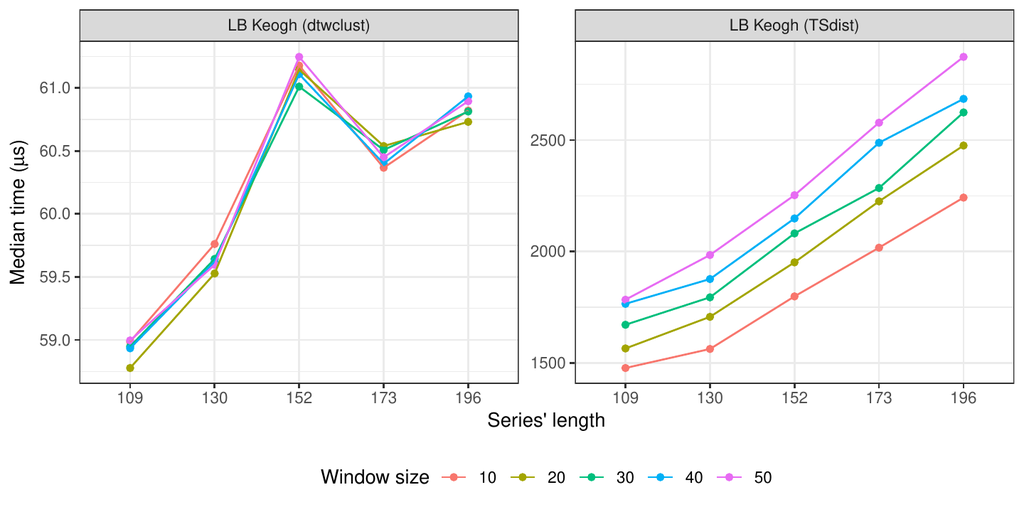

Figure 5: Execution times of two implementations of `LB_Keogh` considering different time series lengths and window sizes. Note the different vertical scales, although both are in microseconds. The package of each implementation is written between parentheses.

Similarly, the DTW distance is also available in the *dtw* package, and possesses a C core. The `dtw_basic` version included with *dtwclust* only supports a slanted window constraint (or none at all), and the `symmetric1` and `symmetric2` step patterns, so it performs less checks, and uses a memory-saving version where only 2 rows of the LCM are saved at a time. As with `LB_Keogh`, a comparison of the DTW implementations’ execution times can be seen in 6.

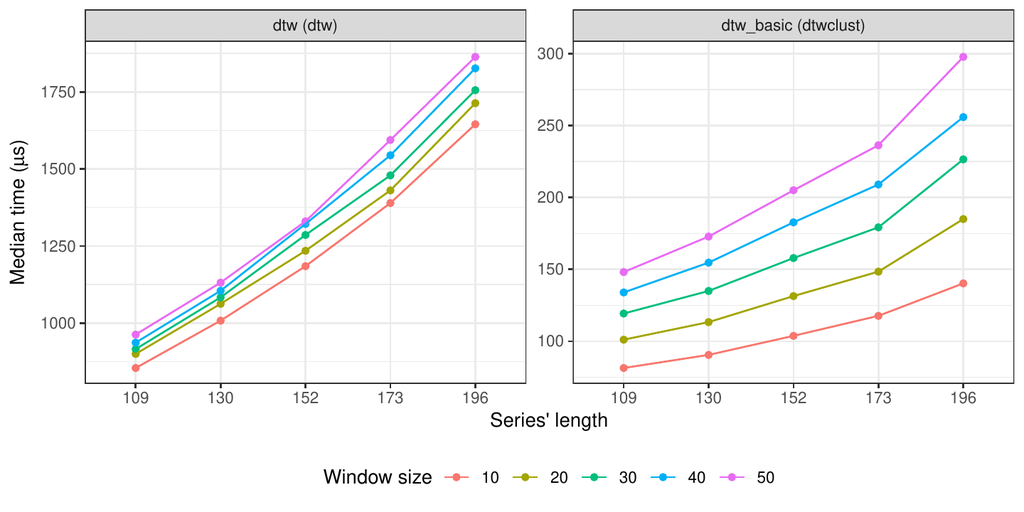

Figure 6: Execution times of two implementations of DTW considering different time series lengths and window sizes. Note the different vertical scales, although both are in microseconds. The package of each implementation is written between parentheses.

The time difference in single calculations is not so dramatic, but said differences accumulate when calculating cross-distance matrices, and become much more significant. The behavior of `LB_Keogh` can be seen in 7, with a fixed window size of 30 and series of length 100. The implementation in *dtwclust* performs the whole calculation in C++, and only calculates the necessary warping envelopes once, although it can be appreciated that this does not have a significant effect.

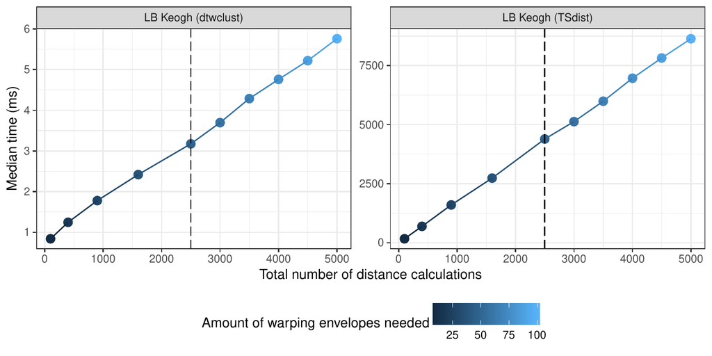

Figure 7: Execution times of the two implementations of `LB_Keogh` when calculating cross-distance matrices. The points on the left of the dashed line represent square matrices, whereas the ones on the right only have one dimension of the cross-distance matrix increased (the one that results in more envelope calculations). Note the different vertical scales, although both are in milliseconds. The package of each implementation is written between parentheses.

The behavior of the DTW implementations can be seen in 8. The *dtwclust* version is an order of magnitude faster, even single-threaded, and it can benefit from parallelization essentially proportionally to the number of threads available.

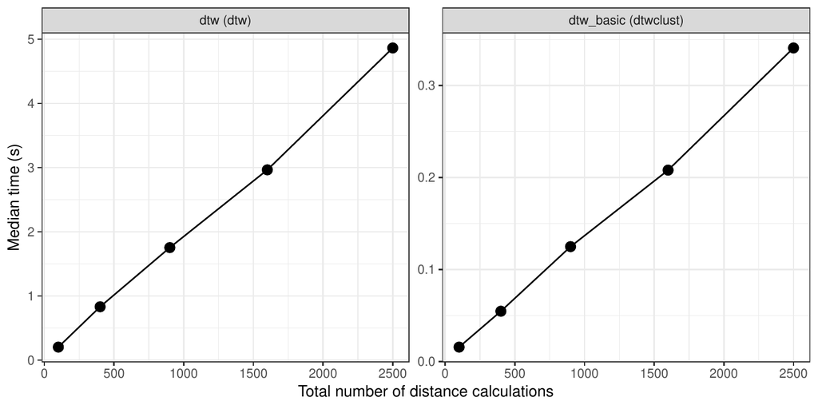

Figure 8: Execution times of the two implementations of DTW when calculating cross-distance matrices. Note the different vertical scales, although both are in seconds. The package of each implementation is written between parentheses.

## 3 Time-series prototypes

A very important step of time-series clustering is the calculation of so-called time-series prototypes. It is expected that all series within a cluster are similar to each other, and one may be interested in trying to define a time-series that effectively summarizes the most important characteristics of all series in a given cluster. This series is sometimes referred to as an average series, and prototyping is also sometimes called time-series averaging, but we will prefer the term “prototyping”, although calling them time-series centroids is also common.

Computing prototypes is commonly done as a sub-routine of a larger task. In the context of clustering (see 4), partitional procedures rely heavily on the prototyping function, since the resulting prototypes are used as cluster centroids. Prototyping could even be a pre-processing step, whereby different samples from the same source can be summarized before clustering (e.g., for the character trajectories dataset, all trajectories from the same character can be summarized and then groups of similar characters could be sought), thus reducing the amount of data and execution time. Another example is time-series classification based on nearest-neighbors, which can be optimized by considering only group-prototypes as neighbors instead of the union of all groups. Nevertheless, it is important to note that the distance used in the overall task should be congruent with the chosen centroid, e.g., using the DTW distance for DTW-based prototypes.

The choice of prototyping function is closely related to the chosen distance measure and, in a similar fashion, it is not simple to know which kind of prototype will be better a priori. There are several strategies available for time-series prototyping, although due to their high dimensionality, what exactly constitutes an average time-series is debatable, and some notions could worsen performance significantly. The following sections will briefly describe some of the common approaches when dealing with time-series.

### 3.1 Partition around medoids

One approach is to use partition around medoids (PAM). A medoid is simply a representative object from a cluster, in this case also a time-series, whose average distance to all other objects in the same cluster is minimal. Since the medoid object is always an element of the original data, PAM is sometimes preferred over mean or median so that the time-series structure is not altered.

A possible advantage of PAM is that, since the data does not change, it is possible to precompute the whole distance matrix once and re-use it on each iteration, and even across different number of clusters and random repetitions. However, this is not suitable for large datasets since the whole distance matrix has to be allocated at once.

In the implementation included in the package, the distances between all member series are computed, and the series with minimum sum of distances is chosen as the prototype.

### 3.2 DTW barycenter averaging

The DTW distance is used very often when working with time-series, and thus a prototyping function based on DTW has also been developed in Petitjean et al. (2011). The procedure is called DTW barycenter averaging (DBA), and is an iterative, global method. The latter means that the order in which the series enter the prototyping function does not affect the outcome.

DBA requires a series to be used as reference (centroid), and it usually begins by randomly selecting one of the series in the data. On each iteration, the DTW alignment between each series in the cluster $C$ and the centroid is computed. Because of the warping performed in DTW, it can be that several time-points from a given time-series map to a single time-point in the centroid series, so for each time-point in the centroid, all the corresponding values from all series in $C$ are grouped together according to the DTW alignments, and the mean is computed for each centroid point using the values contained in each group. This is iteratively repeated until a certain number of iterations are reached, or until convergence is assumed.

The *dtwclust* implementation of DBA is done in C++ and includes several memory optimizations. Nevertheless, it is more computationally expensive due to all the DTW calculations that must be performed. However, it is very competitive when using the DTW distance and, thanks to DTW itself, it can support series with different length directly, with the caveat that the length of the resulting prototype will be the same as the length of the reference series that was initially chosen by the algorithm, and that the `symmetric1` or `symmetric2` step pattern should be used.

### 3.3 Soft-DTW centroid

Thanks to the gradient that can be computed as a by-product of the soft-DTW distance calculation (see 2.3), it is possible to define an objective function (see Equation (4) in Cuturi and Blondel (2017)) and subsequently minimize it with numerical optimization. In addition to the smoothing parameter of soft-DTW ($\gamma$), the optimization procedure considers the option of using normalizing weights for the input series, which noticeably alters the resulting centroids (see Figure 4 in Cuturi and Blondel (2017)). The clustering and classification experiments performed by Cuturi and Blondel (2017) showed that using soft-DTW (distance and centroid) provided quantitatively better results in many scenarios.

### 3.4 Shape extraction

A recently proposed method to calculate time-series prototypes is termed shape extraction, and is part of the *k*-Shape algorithm (see 4.0.2) described in Paparrizos and Gravano (2015). As with the corresponding SBD (see 2.4), the algorithm depends on NCCc, and it first uses it to match two series optimally. 9 depicts the alignment that is performed using two sample series.

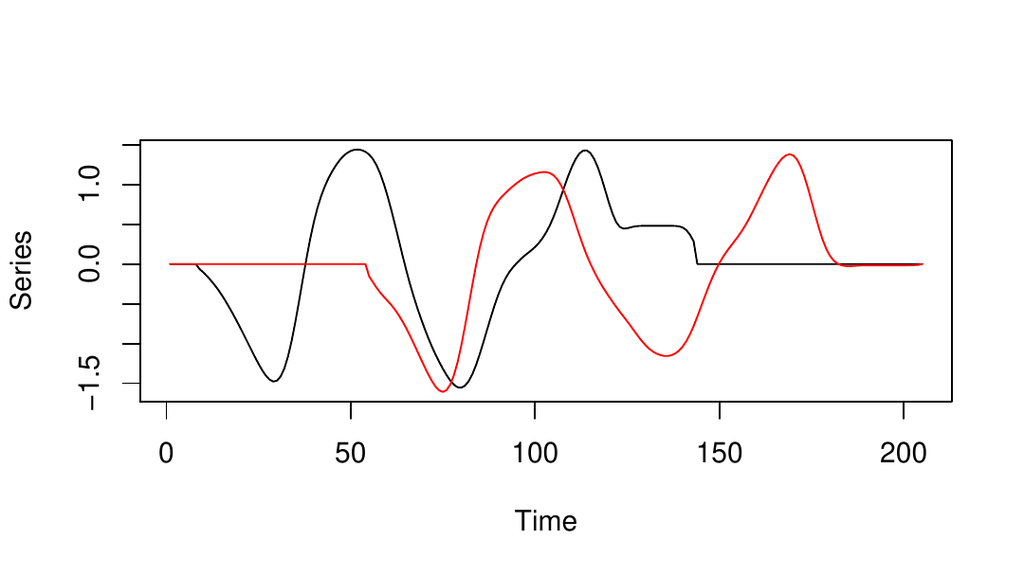

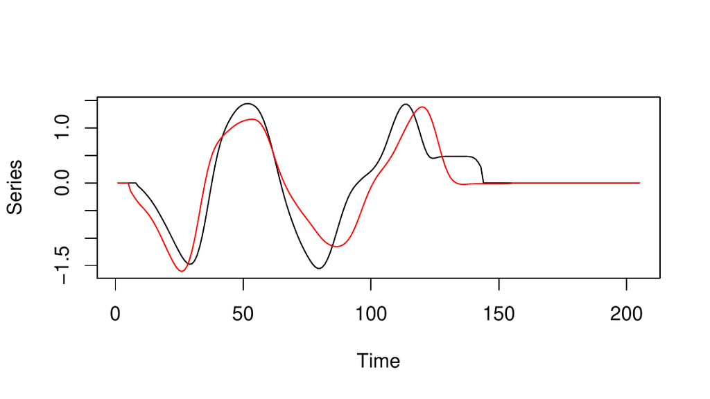

1. Series before alignment
2. Series after alignment

Figure 9: Visualization of the NCCc-based alignment performed on two sample series. After alignment, the second (red) series is either truncated and/or prepended/appended with zeros so that its length matches the first(black) series.

As with DBA, a centroid series is needed, so one is usually randomly chosen from the data. An exception is when all considered time-series have the same length, in which case no centroid is needed beforehand. The alignment can be done between series with different length, and since one of the series is shifted in time, it may be necessary to truncate and prepend or append zeros to the non-reference series, so that the final length matches that of the reference. This is because the final step of the algorithm builds a matrix with the matched series (row-wise) and performs a so-called maximization of Rayleigh Quotient to obtain the final prototype; see Paparrizos and Gravano (2015) for more details.

The output series of the algorithm must be *z*-normalized. Thus, the input series as well as the reference series must also have this normalization. Even though the alignment can be done between series with different length, it has the same caveat as DBA, namely that the length of the resulting prototype will depend on the length of the chosen reference. Technically, for multivariate series, the shape extraction algorithm could be applied for each variable $v$ of all involved series, but this was not explored by the authors of *k*-Shape.

### 3.5 Summary of prototyping functions

2 summarizes the time-series prototyping functions implemented in *dtwclust*, including the distance measure they are based upon, where applicable. It is worth mentioning that, as will be described in 4, the choice of distance and prototyping function is very important for time-series clustering, and it may be ill-advised to use a distance measure that does not correspond to the one used by the prototyping function. Using PAM is an exception, because the medoids are not modified, so any distance can be used to choose a medoid. It is possible to use custom prototyping functions for time-series clustering (see 4.1), but it is important to maintain congruence with the chosen distance measure.

Table 2: Time-series prototyping functions implemented in *dtwclust*, and their corresponding distance measures.

| Prototyping function | Distance used | Algorithm used |
| --- | --- | --- |
| PAM | — | Time-series with minimum sum of distances to the other series in the group. |
| DBA | DTW | Average of points grouped according to DTW alignments. |
| Soft-DTW centroid | Soft-DTW | Numerical optimization using the derivative of soft-DTW. |
| Shape extraction | SBD | Normalized eigenvector of a matrix created with SBD-aligned series. |

## 4 Time-series clustering

There are several clustering algorithms, but in general, they fall within 3 categories: hierarchical clustering, which induces a hierarchy in the data; partitional clustering, which creates crisp partitions of data; and fuzzy clustering, which creates fuzzy or overlapping partitions.

Hierarchical clustering is an algorithm that tries to create a hierarchy of groups in which, as the level in the hierarchy increases, clusters are created by merging the clusters from the next lower level, such that an ordered sequence of groupings is obtained; this may be deceptive, as the algorithms impose the hierarchical structure even if such structure is not inherent to the data (Hastie et al. 2009). In order to decide how the merging is performed, a (dis)similarity measure between groups should be specified, in addition to the one that is used to calculate pairwise similarities. However, a specific number of clusters does not need to be specified for the hierarchy to be created, and the procedure is deterministic, so it will always give the same result for a chosen set of (dis)similarity measures.

Hierarchical clustering has the disadvantage that the whole distance matrix must be calculated for a given dataset, which in most cases has a time and memory complexity of $O(N^2)$ if $N$ is the total number of objects in the dataset. Thus, hierarchical procedures are usually used with relatively small datasets.

Partitional clustering is a strategy used to create partitions. In this case, the data is explicitly assigned to one and only one cluster out of $k$ total clusters. The number of desired clusters must be specified beforehand, which can be a limiting factor. Some of the most popular partitional algorithms are *k*-means and *k*-medoids (Hastie et al. 2009). These use the Euclidean distance and, respectively, mean or PAM centroids (see 3).

Partitional clustering algorithms commonly work in the following way. First, $k$ centroids are randomly initialized, usually by choosing $k$ objects from the dataset at random; these are assigned to individual clusters. The distance between all objects in the data and all centroids is calculated, and each object is assigned to the cluster of its closest centroid. A prototyping function is applied to each cluster to update the corresponding centroid. Then, distances and centroids are updated iteratively until a certain number of iterations have elapsed, or no object changes clusters any more. Most of the proposed algorithms for time-series clustering use the same basic strategy while changing the distance and/or centroid function.

Partitional clustering procedures are stochastic due to their random start. Thus, it is common practice to test different starting points to evaluate several local optima and choose the best result out of all the repetitions. It tends to produce spherical clusters, but has a lower complexity, so it may be applied to very large datasets.

In crisp partitions, each member of the data belongs to only one cluster, and clusters are mutually exclusive. By contrast, fuzzy clustering creates a fuzzy or soft partition in which each member belongs to each cluster to a certain degree. For each member of the data, the degree of belongingness is constrained so that its sum equals 1 across all clusters. Therefore, if there are $N$ objects in the data and $k$ clusters are desired, an $N \times k$ membership matrix $u$ can be created, where all the rows must sum to 1 (note that some authors use the transposed version of $u$).

Technically, fuzzy clustering can be repeated several times with different random starts, since $u$ is initialized randomly. However, comparing the results would be difficult, since it could be that the values within $u$ are shuffled but the overall fuzzy grouping remains the same, or changes very slightly, once the algorithm has converged. Note that it is straightforward to change the fuzzy partition to a crisp one by taking the argument of the row-wise maxima of $u$ and assigning the respective series to the corresponding cluster only.

The main clustering function in *dtwclust* is `tsclust`, which supports all of the aforementioned clustering algorithms. Part of this support comes from functionality provided by other R packages. However, the advantage of using *dtwclust* is that it can handle time-series nuances, like series with different lengths and multivariate series. This is particularly important for partitional clustering, where both distance and prototyping functions must be applicable to time-series data. For brevity, the following sections will focus on describing the new clustering algorithms implemented in *dtwclust*, but more information can be obtained in the functions’ documentation.

#### TADPole clustering

TADPole clustering was proposed in Begum et al. (2015), and is implemented in *dtwclust* in the `TADPole` function. It adopts a relatively new clustering framework and adapts it to time-series clustering with the DTW distance. Because of the way the algorithm works, it can be considered a kind of PAM clustering, since the centroids are always elements of the data. However, this algorithm is deterministic depending on the value of a cutoff distance ($d_c$).

The algorithm first uses the DTW distance’s upper and lower bounds (Euclidean distance and `LB_Keogh` respectively) to find series with many close neighbors (in DTW space). Anything below $d_c$ is considered a neighbor. Aided with this information, the algorithm then tries to prune as many DTW calculations as possible in order to accelerate the clustering procedure. The series that lie in dense areas (i.e., that have lots of neighbors) are taken as cluster centroids. For a more detailed explanation of each step, please refer to Begum et al. (2015).

TADPole relies on the DTW bounds, which are only defined for time-series of equal length. Consequently, it requires a Sakoe-Chiba constraint. Furthermore, it should be noted that the Euclidean distance is only valid as a DTW upper bound if the `symmetric1` step pattern is used (see 2). Finally, the allocation of several distance matrices is required, making it similar to hierarchical procedures memory-wise, so its applicability is limited to relatively small datasets.

#### *k*-Shape clustering

The *k*-Shape clustering algorithm was developed by Paparrizos and Gravano (2015). It is a partitional clustering algorithm with a custom distance measure (SBD; see 2.4), as well as a custom centroid function (shape extraction; see 3.4). It is also stochastic in nature, and requires *z*-normalization in its default definition. In order to use this clustering algorithm, the `tsclust` function should be called with partitional as the clustering type, SBD as the distance measure, shape extraction as the centroid function, and *z*-normalization as the preprocessing step. As can be appreciated, this algorithm uses the same strategy as *k*-means, but replaces both distance and prototying functions with custom ones that are congruent with each other.

### 4.1 Clustering examples

In this example, three different partitional clustering strategies are used: the $\text{DTW}_2$ distance and DBA centroids, *k*-Shape, and finally TADPole. The results are evaluated using Variation of Information (see 5), with lower numbers indicating better results. Note that *z*-normalization is applied by default when selecting shape extraction as the centroid function. For consistency, all algorithms used the reinterpolated and normalized data, since some algorithms require series of equal length. A subset of the data is used for speed. The outcome should not be generalized to other data, and normalization/reinterpolation may actually worsen some of the algorithms’ performance.

```r
# Linear reinterpolation to same length
data <- reinterpolate(CharTraj, new.length = max(lengths(CharTraj)))
# z-normalization
data <- zscore(data[60L:100L])

pc_dtw <- tsclust(data, k = 4L, seed = 8L,
                  distance = "dtw_basic", centroid = "dba",
                  norm = "L2", window.size = 20L)

pc_ks <- tsclust(data, k = 4L, seed = 8L,
                 distance = "sbd", centroid = "shape")

pc_tp <- tsclust(data, k = 4L, type = "tadpole", seed = 8L,
                 control = tadpole_control(dc = 1.5, window.size = 20L))

sapply(list(DTW = pc_dtw, kShape = pc_ks, TADPole = pc_tp),
       cvi, b = CharTrajLabels[60L:100L], type = "VI")

   DTW.VI  kShape.VI TADPole.VI
0.5017081  0.4353306  0.4901096
```

As can be seen, using a distance registered with *proxy* can be done by simply specifying its name in the `distance` argument of `tsclust`. Using the prototyping functions included in *dtwclust* can be done by passing their respective names in the `centroid` parameter, but using a custom prototyping function is also possible. For example, a weighted mean centroid is implemented as follows. The usefulness of such an approach is of course questionable.

```r
weighted_mean_cent <- function(x, cl_id, k, cent, cl_old, ..., weights) {
    x <- Map(x, weights, f = function(ts, w) { w * ts })
    x_split <- split(x, cl_id)
    new_cent <- lapply(x_split, function(xx) {
        xx <- do.call(rbind, xx)
        colMeans(xx)
    })
}

data <- reinterpolate(CharTraj, new.length = max(lengths(CharTraj)))
weights <- rep(c(0.9,1.1), each = 5L)
tsclust(data[1L:10L], type = "p", k = 2L,
        distance = "Manhattan",
        centroid = weighted_mean_cent,
        seed = 123,
        args = tsclust_args(cent = list(weights = weights)))

partitional clustering with 2 clusters
Using manhattan distance
Using weighted_mean_cent centroids

Time required for analysis:
user  system elapsed
0.024   0.000   0.023

Cluster sizes with average intra-cluster distance:

size  av_dist
1    5 15.05069
2    5 18.99145
```

## 5 Cluster evaluation

Clustering is commonly considered to be an unsupervised procedure, so evaluating its performance can be rather subjective. However, a great amount of effort has been invested in trying to standardize cluster evaluation metrics by using cluster validity indices (CVIs). Many indices have been developed over the years, and they form a research area of their own, but there are some overall details that are worth mentioning. The discussion here is based on Arbelaitz et al. (2013) and Wang and Zhang (2007), which provide a much more comprehensive overview.

In general, CVIs can be either tailored to crisp or fuzzy partitions. For the former, CVIs can be classified as internal, external or relative depending on how they are computed. Focusing on the first two, the crucial difference is that internal CVIs only consider the partitioned data and try to define a measure of cluster purity, whereas external CVIs compare the obtained partition to the correct one. Thus, external CVIs can only be used if the ground truth is known.

Note that even though a fuzzy partition can be changed into a crisp one, making it compatible with many of the existing “crisp” CVIs, there are also fuzzy CVIs tailored specifically to fuzzy clustering, and these may be more suitable in those situations. Fuzzy partitions usually have no ground truth associated with them, but there are exceptions depending on the task’s goal (Lei et al. 2017).

Several of the best-performing CVIs according to Wang and Zhang (2007), Arbelaitz et al. (2013), and (Lei et al. 2017) are implemented in *dtwclust* in the `cvi` function. 3 specifies which ones are available and some of their particularities.

Table 3: Cluster validity indices included in *dtwclust*. The first four are calculated with the `comPart` function from the *flexclust* package. The Silhouette index is calculated with the `silhouette` function in the *cluster* package. Internal fuzzy CVIs use the nomenclature from (Wang and Zhang 2007).

| CVI | Internal or external | Crisp or fuzzy partitions | Minimized or Maximized | Considerations |
| --- | --- | --- | --- | --- |
| Rand | External | Crisp | Maximized | — |
| Adjusted rand | External | Crisp | Maximized | — |
| Jaccard | External | Crisp | Maximized | — |
| Fowlkes-Mallows | External | Crisp | Maximized | — |
| Variation of information | External | Crisp | Minimized | — |
| Soft rand | External | Fuzzy | Maximized | — |
| Soft adjusted rand | External | Fuzzy | Maximized | — |
| Soft variation of information | External | Fuzzy | Minimized | — |
| Soft normalized mutual information | External | Fuzzy | Maximized | — |
| Silhouette | Internal | Crisp | Maximized | Requires the whole cross-distance matrix. |
| Dunn | Internal | Crisp | Maximized | Requires the whole cross-distance matrix. |
| COP | Internal | Crisp | Minimized | Requires the whole cross-distance matrix. |
| Davies-Bouldin | Internal | Crisp | Minimized | Calculates distances to the computed cluster centroids. |
| Modified Davies-Bouldin (DB*) | Internal | Crisp | Minimized | Calculates distances to the computed cluster centroids. |
| Calinski-Harabasz | Internal | Crisp | Maximized | Calculates a global centroid. |
| Score function | Internal | Crisp | Maximized | Calculates a global centroid. |
| MPC | Internal | Fuzzy | Maximized | — |
| K | Internal | Fuzzy | Minimized | Calculates a global centroid. |
| T | Internal | Fuzzy | Minimized | — |
| SC | Internal | Fuzzy | Maximized | Calculates a global centroid. |
| PBMF | Internal | Fuzzy | Maximized | Calculates a global centroid. |

There are some advantages and corresponding caveats with respect to the *dtwclust* implementations. Many internal CVIs require additional distance calculations, and some also compute so-called global centroids (a centroid that uses the whole dataset), which were calculated with, respectively, the Euclidean distance and a mean centroid in the original definition. The implementations in *dtwclust* change this, making use of whatever distance/centroid was utilized during clustering without further intervention from the user, so it is possible to leverage the distance and centroid functions that support time-series. Nevertheless, many CVIs assume symmetric distance functions, so the `cvi` function warns the user when this is not fulfilled.

Knowing which CVI will work best cannot be determined a priori, so they should be tested for each specific application. Many CVIs can be utilized and compared to each other, maybe using a majority vote to decide on a final result, but there is no best CVI, and it is important to conceptually understand what a given CVI measures in order to appropriately interpret its results. Furthermore, it should be noted that, due to additional distance and/or centroid calculations, computing CVIs can be prohibitive in some cases. For example, the Silhouette index effectively needs the whole distance matrix between the original series to be calculated.

CVIs are not the only way to evaluate clustering results. The [*clue*](https://CRAN.R-project.org/package=clue) package (Hornik 2005, 2019) includes its own extensible framework for evaluation of cluster ensembles. It does not directly deal with the clustering algorithms themselves, rather with ways of quantifying agreement and consensus between several clustering results. As such, it is directly compatible with the results from *dtwclust*, since it does not care how a partition/hierarchy was created. Support for the *clue* package framework is included.

### 5.1 Cluster evaluation examples

```r
# subset
data <- CharTraj[1L:20L]
pc_k <- tsclust(data, k = 3L:5L, seed = 94L,
                distance = "dtw_basic", centroid = "pam")
names(pc_k) <- paste0("k_", 3L:5L)
sapply(pc_k, cvi, type = "internal")
                k_3          k_4          k_5
Sil    6.897035e-01 7.295148e-01 6.726453e-01
SF     1.105005e-11 1.345888e-10 1.074494e-10
CH     2.375816e+01 2.873765e+01 2.207096e+01
DB     4.141004e-01 3.225955e-01 2.858009e-01
DBstar 4.799175e-01 4.998963e-01 7.029138e-01
D      1.054228e+00 7.078230e-01 4.430916e-01
COP    1.176921e-01 7.768459e-02 7.153216e-02
```

If we choose the value of $k = 4$, we could then compare results among different random repetitions with help of the *clue* package (or with CVIs again).

```r
require("clue")

pc_4 <- tsclust(data, type = "p", k = 4L,
                distance = "dtw_basic", centroid = "pam",
                control = partitional_control(nrep = 5L),
                seed = 95L)

names(pc_4) <- paste0("r_", 1L:5L)
pc_4 <- cl_ensemble(list = pc_4)
cl_dissimilarity(pc_4)

Dissimilarities using minimal Euclidean membership distance:
         r_1      r_2      r_3      r_4
r_2 3.464102
r_3 0.000000 3.464102
r_4 0.000000 3.464102 0.000000
r_5 0.000000 3.464102 0.000000 0.000000

table(Medoid = cl_class_ids(cl_medoid(pc_4)),
      "True Classes" = rep(c(4L, 3L, 1L, 2L), each = 5L))
       True Classes
Medoid 1 2 3 4
     1 5 0 0 0
     2 0 5 0 0
     3 0 0 5 0
     4 0 0 0 5
```

## 6 Comparing clustering algorithms with *dtwclust*

As we have seen, there are several aspects that must be considered for time-series clustering. Some examples are:

- Pre-processing of data, possibly changing the decision space.
- Type of clustering (partitional, hierarchical, etc.).
- Number of desired or expected clusters.
- Choice of distance measure, along with its parameterization.
- Choice of centroid function and its parameterization. This may also depend on the chosen distance.
- Evaluation of clustering results.
- Computational cost, which depends not only on the size of the dataset, but also on the complexity of the aforementioned aspects.

In order to facilitate more laborious workflows, *dtwclust* includes the `compare_clusterings` function which, along with its helper functions, optimizes the way the different clustering algorithms can be executed. Its main advantage is that it leverages parallelization. Using parallelization is not something that is commonly explored explicitly in the literature, but it can be extremely useful in practical applications. In the case of time-series clustering, parallel computation can result in a very significant reduction in execution times.

Handling parallelization has been greatly simplified in R by different software packages. The implementations done in *dtwclust* use the [*foreach*](https://CRAN.R-project.org/package=foreach) package (Revolution Analytics and Weston 2017) for multi-processing, and [*RcppParallel*](https://CRAN.R-project.org/package=RcppParallel) for multi-threading (Allaire et al. 2018). Thanks to *foreach*, the parallelized workflow can be executed not only in a local machine, but also in a computing cluster. In order to avoid data copies and communication overhead in these scenarios, `compare_clusterings` is coded in a way that, by default, less data is returned from the parallel processes. Nevertheless, as will be shown shortly, the results can be fully re-created in the main process on demand.

With this infrastructure, it is possible to cover the whole clustering workflow with *dtwclust*.

### 6.1 Parallelized workflow example

This example uses the [*doParallel*](https://CRAN.R-project.org/package=doParallel) package (Microsoft Corporation and Weston 2018), which is one of the options that provides a parallel backend for *foreach*.

The configuration is specified with two helper functions: `compare_clusterings_configs` and `pdc_configs`. It tests partitional clustering with DTW distance and DBA centroids, exploring different values for window size and norm. The value of the window size can have a very significant effect on clustering quality (Dau et al. 2016) [^3], but there is no single size that performs best on all datasets, so it is important to assess its effect on each specific case.

Since the ground truth is known in this scenario, an external CVI is chosen for evaluation: the adjusted Rand index. The `cvi_evaluators` function generates functions that can be passed to `compare_clusterings` which, internally, use the `cvi` function (see 5).

```r
require("doParallel")
workers <- makeCluster(detectCores())
invisible(clusterEvalQ(workers, library(dtwclust)))
registerDoParallel(workers)

cfg <- compare_clusterings_configs(
    types = "partitional",
    k = 20L,
    controls = list(
        partitional = partitional_control(
            iter.max = 20L
        )
    ),
    distances = pdc_configs(
        "distance",
        partitional = list(
            dtw_basic = list(
                window.size = seq(from = 10L, to = 30L, by = 5L),
                norm = c("L1", "L2")
            )
        )
    ),
    centroids = pdc_configs(
        "centroid",
        share.config = c("p"),
        dba = list(
            window.size = seq(from = 10L, to = 30L, by = 5L),
            norm = c("L1", "L2")
        )
    ),
    no.expand = c(
        "window.size",
        "norm"
    )
)

evaluators <- cvi_evaluators("ARI", ground.truth = CharTrajLabels)

comparison <- compare_clusterings(CharTraj, types = "partitional",
                                  configs = cfg, seed = 8L,
                                  score.clus = evaluators$score,
                                  pick.clus = evaluators$pick)

stopCluster(workers); registerDoSEQ()

# some rows and columns from the results data frame
head(comparison$results$partitional[, c("config_id", "distance", "centroid",
                                        "window.size_distance", "norm_distance",
                                        "ARI")])
  config_id  distance centroid window.size_distance norm_distance       ARI
1   config1 dtw_basic      dba                   10            L1 0.6021905
2   config2 dtw_basic      dba                   10            L2 0.6589223
3   config3 dtw_basic      dba                   15            L1 0.5306598
4   config4 dtw_basic      dba                   15            L2 0.4733479
5   config5 dtw_basic      dba                   20            L1 0.4474698
6   config6 dtw_basic      dba                   20            L2 0.5840729
```

Based on the ARI, one of the configurations was picked as the best one, and it is possible to obtain the clustering object by calling `repeat_clustering`:

```r
clusters <- repeat_clustering(CharTraj, comparison, comparison$pick$config_id)

matrix(clusters@cluster, ncol = 5L, byrow = TRUE)
      [,1] [,2] [,3] [,4] [,5]
 [1,]    5    5    5    5    5
 [2,]    7    7    7    7    7
 [3,]   18   18   18   18   18
 [4,]   15   15   15   15   15
 [5,]   17   17   17   17   17
 [6,]    4    4    4    4    9
 [7,]    2    2    2    2    2
 [8,]    3    3    3    3   11
 [9,]    6    6    6    6    6
[10,]   20   20   20   20   20
[11,]   10   10   10   10   10
[12,]   10   19   19   19   19
[13,]   20   20   20   20   12
[14,]   14    8   16    8    8
[15,]    4    4    4    4    4
[16,]    2    2    2    2    2
[17,]    1    1    1   14    1
[18,]    6    6    6    6    6
[19,]   13   13   13   13    9
[20,]   18   12   17   17   17
```

## 7 Conclusion

In this manuscript a general overview of shape-based time-series clustering was provided. This included a lot of information related to the DTW distance and its corresponding optimizations, such as constraints and lower bounding techniques. At the same time, the *dtwclust* package for R was described and showcased, demonstrating how it can be used to test and compare different procedures efficiently and unbiasedly by providing a common infrastructure.

The package implements several different routines, most of which are related to the DTW algorithm. Nevertheless, its modular structure enables the user to customize and complement the included functionality by means of custom algorithms or even other R packages, as it was the case with *TSdist* and *clue*. These packages are more specialized, dealing with specific tasks (respectively: distance calculations and cluster evaluation). By contrast, *dtwclust* provides a more general purpose clustering workflow, having enough flexibility to allow for the most common approaches to be used.

The goal of this manuscript was not to give a comprehensive and thorough explanation of all the discussed algorithms, but rather to provide information related to what has been done in the literature, including some more recent propositions, so that the reader knows where to start looking for further information, as well as what can or cannot be done with *dtwclust*.

Choosing a specific clustering algorithm for a given application is not an easy task. There are many factors to take into account and it is not possible to know a priori which one will yield the best results. The included implementations try to use the native (and heavily optimized) R functions as much as possible, relying on compiled code where needed, so we hope that, if time-series clustering is required, *dtwclust* can serve as a starting point.

Disclaimer: The software package was developed  
independently of any organization or institution  
that is or has been associated with the author.

### 7.1 Supplementary materials

Supplementary materials are available in addition to this article. It can be downloaded at RJ-2019-023.zip

### 7.2 CRAN packages used

dtwclust, flexclust, cluster, TSdist, TSclust, pdc, dtw, proxy, clue, foreach, RcppParallel, doParallel

### 7.3 CRAN Task Views implied by cited packages

Cluster, Environmetrics, HighPerformanceComputing, Optimization, Robust, TimeSeries

C. C. Aggarwal, A. Hinneburg and D. A. Keim. On the surprising behavior of distance metrics in high dimensional space. In *International conference on database theory*, Eds J. V. den Bussche and V. Vianu pages. 420–434 2001. Springer-Verlag.

C. C. Aggarwal and C. K. Reddy. Time-series data clustering. In *Data clustering: Algorithms and applications*, 2013. CRC Press.

S. Aghabozorgi, A. S. Shirkhorshidi and T. Y. Wah. Time-series clustering — a decade review. *Information Systems*, 53: 16–38, 2015. URL https://doi.org/10.1016/j.is.2015.04.007.

J. Allaire, R. Francois, K. Ushey, G. Vandenbrouck, M. Geelnard and Intel. *RcppParallel: Parallel programming tools for ’Rcpp’.* 2018. URL https://CRAN.R-project.org/package=RcppParallel. R package version 4.4.2.

O. Arbelaitz, I. Gurrutxaga, J. Muguerza, J. M. Pérez and I. Perona. An extensive comparative study of cluster validity indices. *Pattern Recognition*, 46(1): 243–256, 2013. URL https://doi.org/10.1016/j.patcog.2012.07.021.

N. Begum, L. Ulanova, J. Wang and E. Keogh. Accelerating dynamic time warping clustering with a novel admissible pruning strategy. In *Conference on knowledge discovery and data mining*, 2015. ACM. ISBN 978-1-4503-3664-2/15/08. URL https://doi.org/10.1145/2783258.2783286.

D. J. Berndt and J. Clifford. Using dynamic time warping to find patterns in time series. In *KDD workshop*, pages. 359–370 1994. Seattle, WA.

A. M. Brandmaier. pdc: An R package for complexity-based clustering of time series. *Journal of Statistical Software*, 67(5): 1–23, 2015. URL https://doi.org/10.18637/jss.v067.i05.

M. Cuturi. Fast global alignment kernels. In *Proceedings of the 28th international conference on machine learning (ICML-11)*, pages. 929–936 2011.

M. Cuturi and M. Blondel. Soft-DTW: A differentiable loss function for time-series. In *Proceedings of the 34th international conference on machine learning*, Eds D. Precup and Y. W. Teh pages. 894–903 2017. International Convention Centre, Sydney, Australia: PMLR. URL http://proceedings.mlr.press/v70/cuturi17a.html.

H. A. Dau, N. Begum and E. Keogh. Semi-supervision dramatically improves time series clustering under dynamic time warping. In *Proceedings of the 25th ACM international on conference on information and knowledge management*, pages. 999–1008 2016. ACM. URL https://doi.org/10.1145/2983323.2983855.

T. Giorgino. Computing and visualizing dynamic time warping alignments in R: The dtw package. *Journal of Statistical Software*, 31(7): 1–24, 2009. URL https://doi.org/10.18637/jss.v031.i07.

T. Hastie, R. Tibshirani and J. Friedman. Cluster analysis. In *The elements of statistical learning 2nd edition*, 2009. Springer-Verlag.

K. Hornik. A CLUE for CLUster ensembles. *Journal of Statistical Software*, 14(12): 1–25, 2005. URL https://doi.org/10.18637/jss.v014.i12.

K. Hornik. *clue: Cluster ensembles.* 2019. URL https://CRAN.R-project.org/package=clue. R package version 0.3-57.

L. Kaufman and P. J. Rousseeuw. Finding groups in data. An introduction to cluster analysis. In *Wiley Series in Probability and Mathematical Statistics. Applied Probability and Statistics, New York: Wiley, 1990*, 1990. John Wiley & Sons.

E. Keogh and C. A. Ratanamahatana. Exact indexing of dynamic time warping. *Knowledge and information systems*, 7(3): 358–386, 2005. URL https://doi.org/10.1007/s10115-004-0154-9.

Y. Lei, J. C. Bezdek, J. Chan, N. X. Vinh, S. Romano and J. Bailey. Extending information-theoretic validity indices for fuzzy clustering. *IEEE Transactions on Fuzzy Systems*, 25(4): 1013–1018, 2017. URL https://doi.org/10.1109/TFUZZ.2016.2584644.

F. Leisch. A toolbox for k-centroids cluster analysis. *Computational Statistics & Data Analysis*, 51(2): 526–544, 2006. URL https://doi.org/10.1016/j.csda.2005.10.006.

D. Lemire. Faster retrieval with a two-pass dynamic-time-warping lower bound. *Pattern Recognition*, 42(9): 2169–2180, 2009. URL https://doi.org/10.1016/j.patcog.2008.11.030.

T. W. Liao. Clustering of time series data: A survey. *Pattern recognition*, 38(11): 1857–1874, 2005. URL https://doi.org/10.1016/j.patcog.2005.01.025.

M. Lichman. UCI machine learning repository. 2013. URL http://archive.ics.uci.edu/ml.

M. Maechler, P. Rousseeuw, A. Struyf, M. Hubert and K. Hornik. *cluster: Cluster analysis basics and extensions.* 2019. URL https://CRAN.R-project.org/package=cluster. R package version 2.0.8.

D. Meyer and C. Buchta. *proxy: Distance and similarity measures.* 2019. URL https://CRAN.R-project.org/package=proxy. R package version 0.4-23.

Microsoft Corporation and S. Weston. *doParallel: Foreach parallel adaptor for the ’parallel’ package.* 2018. URL https://CRAN.R-project.org/package=doParallel. R package version 1.0.14.

P. Montero and J. A. Vilar. TSclust: An R package for time series clustering. *Journal of Statistical Software*, 62(1): 1–43, 2014. URL https://doi.org/10.18637/jss.v062.i01.

U. Mori, A. Mendiburu and J. A. Lozano. Distance measures for time series in R: The TSdist package. *R Journal*, 8(2): 451–459, 2016. URL https://journal.r-project.org/archive/2016/RJ-2016-058/index.html.

J. Paparrizos and L. Gravano. k-Shape: Efficient and accurate clustering of time series. In *Proceedings of the 2015 ACM SIGMOD international conference on management of data*, pages. 1855–1870 2015. New York, NY, USA: ACM. ISBN 978-1-4503-2758-9. URL https://doi.org/10.1145/2949741.2949758.

F. Petitjean, A. Ketterlin and P. Gançarski. A global averaging method for dynamic time warping, with applications to clustering. *Pattern Recognition*, 44(3): 678–693, 2011. URL https://doi.org/10.1016/j.patcog.2010.09.013.

S. Rani and G. Sikka. Recent techniques of clustering of time series data: A survey. *International Journal of Computer Applications*, 52(15): 2012. URL https://doi.org/10.5120/8282-1278.

C. A. Ratanamahatana and E. Keogh. Everything you know about dynamic time warping is wrong. In *Third workshop on mining temporal and sequential data*, 2004. Citeseer.

Revolution Analytics and S. Weston. *foreach: Provides foreach looping construct for R.* 2017. URL https://CRAN.R-project.org/package=foreach. R package version 1.4.4.

H. Sakoe and S. Chiba. Dynamic programming algorithm optimization for spoken word recognition. *Acoustics, Speech and Signal Processing, IEEE Transactions on*, 26(1): 43–49, 1978. URL https://doi.org/10.1109/TASSP.1978.1163055.

W. Wang and Y. Zhang. On fuzzy cluster validity indices. *Fuzzy sets and systems*, 158(19): 2095–2117, 2007. URL https://doi.org/10.1016/j.fss.2007.03.004.

[^1]: http://marcocuturi.net/GA.html, accessed on 2016-10-29
[^2]: Visible at https://cran.r-project.org/web/packages/dtwclust/vignettes/
[^3]: The strategy presented in this reference is also included in *dtwclust* in the `ssdtwclust` function, and it is implemented by leveraging `compare_clusterings`.